# Statistic Task

Sondre Kaastad Soersdal

31 august 2021

## Loading Packages

```r
#Clear Environment
rm(list = ls())
#Loading packages
if (!require("pacman")) install.packages("pacman")
pacman::p_load(tidyverse, car,knitr,sjPlot,sjmisc,DescTools,
               gridExtra,knitr,kableExtra,PMCMR,FSA,readxl,
               sjlabelled,scales,reshape2,broom,dunn.test)
#Setting options
opts_knit$set(root.dir = "C:/Users/Sondre/Documents/Master/Master-Project/apple")
options(knitr.kable.NA = '')
```

## 1: Comparing the Aphid Shoots Apple by treatment

```r
# Aphid_shoots_Apple data
Aphid_shoots_Apple <- read_excel("Appletrees_insects_v2.xlsx",
                                sheet="Aphid_shoots_apple")
```

### Descriptive statistics of Aphid Shoots by Treatment

```r
aphid_shoots_mean <- data.frame(Aphid_shoots_Apple %>%
                                  group_by(treatment) %>%
                                  summarise(Mean = mean(aphid_shoots),
                                            SD = sd(aphid_shoots),
                                            Minimum = min(aphid_shoots),
                                            Maximum =max(aphid_shoots)))
#Table average of Aphid Shots by treatment
tab_df(aphid_shoots_mean,
       title = "Table 1: Descriptive Statistics of Aphid Shoots Apple by Treatment")
```

Table 1: Descriptive Statistics of Aphid Shoots Apple by Treatment

| treatment | Mean | SD | Minimum | Maximum |
| --- | --- | --- | --- | --- |
| FS1 | 0.33 | 0.82 | 0 | 5 |
| FS1+Insect | 0.66 | 1.16 | 0 | 6 |
| FS14 | 0.42 | 0.94 | 0 | 7 |
| FS14+Insect | 0.62 | 1.35 | 0 | 7 |
| Insect | 0.44 | 0.97 | 0 | 4 |
| NoTreatment | 0.29 | 0.93 | 0 | 6 |

### Checking Normality of Aphid Shoots Apple

For normality, we are conducting a Shapiro-Wilk normality test. The null and alternative hypotheses for this test are given below:

$H_0$: The distribution of Aphid Shoots Apple is normal. $H_1$: The distribution of Aphid Shoots Apple is not normal.

```r
normal_test <- shapiro.test(Aphid_shoots_Apple$aphid_shoots)
noquote("Shapiro-Wilk normality test")
```

```
## [1] Shapiro-Wilk normality test
```

```r
cat("Test Statistic (W) =", 0.50,"\n")
```

```
## Test Statistic (W) = 0.5
```

```r
cat("P-value <", 0.0001,"\n")
```

```
## P-value < 1e-04
```

The P-value of Shapiro-Wilk test is found to be lower than `0.0001`, which suggests that the null hypothesis of the “The distribution of Aphid Shoots Apple is normal”, is rejected. Hence, the Aphid Shoots Apple is not normal, and the Parametric test is not appropriate here.

Since, we need to compare the Aphid Shoots by Treatments, and the treatment groups are more than two. Hence, a non-parametric test (Kruskal-Wallis Test) alternative to One-Way ANOVA, is appropriate to achieve the study purposes.

### Plotting Histogram for checking Shape

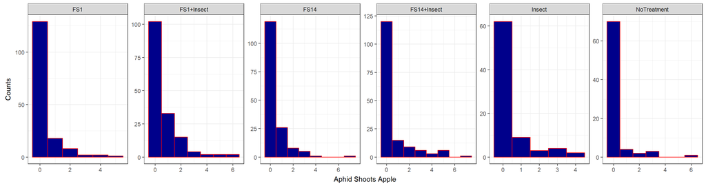

```r
#Converting treatment to factors
Aphid_shoots_Apple$treatment <- as.factor(Aphid_shoots_Apple$treatment)
##Boxplots
Hist_Aphid_Shoots_Apple <- ggplot(Aphid_shoots_Apple,aes(x=aphid_shoots))+
  geom_histogram(fill="darkblue",col="red",binwidth = 1)+xlab("Aphid Shoots Apple")+ylab("")+
  facet_wrap(treatment~.,scales = "free",ncol=7)+
  theme_bw()+ylab("Counts");Hist_Aphid_Shoots_Apple
```

```r
#Save plot
ggsave("Hist_Aphid_Shoots_Apple.tiff", units="in", width=15, height=5, dpi=300, compression = 'lzw')
```

Histograms suggesting that the shapes of distributions of the Aphid Shoots Apple are different than each other, as some of them are highly skewed, and some of these are slightly skewed, ans their variablity is different. Hence, the mean comaprison through Kruskal Wallis test is appropriate here.

### Implementing Kruskal Wallis Test

The null and alternative hypotheses for this test are given below:

$H_0$: There is no difference in average Aphid Shoots Apple by treatments. $H_1$: There is a difference in average Aphid Shoots Apple by treatments.

```r
#Kruskal Wallis test
kstest1 <- kruskal.test(aphid_shoots~treatment,Aphid_shoots_Apple)
#Reporting results
noquote("Results of Kruskal-Wallis H Test")
```

```
## [1] Results of Kruskal-Wallis H Test
```

```r
cat("Kruskal-Wallis chi-squared =",19,"\n")
```

```
## Kruskal-Wallis chi-squared = 19
```

```r
cat("Degree of Freedom =",5,"\n")
```

```
## Degree of Freedom = 5
```

```r
cat("P-value =","0.0002","\n")
```

[output not shown]

It can be observed that the p-value of Kruskal-Wallis test is lower than `0.05` (level of significance). Hence, the null hypothesis will be rejected, and it is concluded that there is a significant difference in the average Aphid Shoots Apple by treatments.

For comparing the average significant difference in each pair of treatments, we conducted Dunn’s Test, which is post-hoc test, and used when the null hypothesis if Kruskal-Wallis test is rejected. Also, for visual comparison, we have plotted the average and error-bars for Aphid Shoots Apple by Treatments.

### Dunn’s Test for checking significant difference of Aphid Shoots by Treatment

```r
#Computing all pairwise average differences
Mean_Diff <-TukeyHSD(aov(aphid_shoots~treatment,Aphid_shoots_Apple))$treatment %>%
  data.frame() %>%rownames_to_column(.,var="Pairs") %>%
  mutate(Difference=round(diff,3)) %>%
  select(1,6)

#Calculating p-values for sinficance of average differences, using bonferroni method
options(scipen = 999)
dun_test <- dunnTest(aphid_shoots~treatment,Aphid_shoots_Apple,method="bonferroni")
dun_test
```

```
##                   Comparison          Z      P.unadj       P.adj
## 1           FS1 - FS1+Insect -3.4269196 0.0006104698 0.009157047
## 2                 FS1 - FS14 -1.1986298 0.2306719193 1.000000000
## 3          FS1+Insect - FS14  2.2282898 0.0258611968 0.387917952
## 4          FS1 - FS14+Insect -1.4866466 0.1371081754 1.000000000
## 5   FS1+Insect - FS14+Insect  1.9402730 0.0523465192 0.785197788
## 6         FS14 - FS14+Insect -0.2880168 0.7733338972 1.000000000
## 7               FS1 - Insect -0.6248849 0.5320466030 1.000000000
## 8        FS1+Insect - Insect  2.1731832 0.0297665287 0.446497930
## 9              FS14 - Insect  0.3537922 0.7234945852 1.000000000
## 10      FS14+Insect - Insect  0.5889570 0.5558901472 1.000000000
## 11         FS1 - NoTreatment  1.0074195 0.3137332243 1.000000000
## 12  FS1+Insect - NoTreatment  3.8054876 0.0001415251 0.002122876
## 13        FS14 - NoTreatment  1.9860966 0.0470225936 0.705338904
## 14 FS14+Insect - NoTreatment  2.2212614 0.0263332644 0.394998966
## 15      Insect - NoTreatment  1.4136171 0.1574743642 1.000000000
```

```r
#creating vector of p.adjusted so that it fits the arrangement of Mean_Diff
P.adj <-c(0.009157047, 1.000000000, 1.000000000,    1.000000000, 1.000000000, 0.387917952, 0.785197788, 0.446497930, 0.002122876,   1.000000000,    1.000000000,    0.705338904, 1.000000000,   0.394998966, 1.000000000)
#Creating table of results
Post_Hoc <- cbind(Mean_Diff, P.adj = P.adj)

#Filtering out unrelevant pairings
Post_Hoc <- Post_Hoc %>%
  filter(Pairs %in% c("FS14-FS1", "NoTreatment-FS1", "FS14+Insect-FS1+Insect", "Insect-FS1+Insect", "NoTreatment-FS14", "Insect-FS14+Insect"))

# Creating Table
tab_df(Post_Hoc,title = "Table 2: Post-Hoc Aphid Shoots Apple by Treatment",digits = 3)
```

Table 2: Post-Hoc Aphid Shoots Apple by Treatment

| Pairs | Difference | P.adj |
| --- | --- | --- |
| FS14-FS1 | 0.094 | 1.000 |
| NoTreatment-FS1 | -0.044 | 1.000 |
| FS14+Insect-FS1+Insect | -0.031 | 0.785 |
| Insect-FS1+Insect | -0.219 | 0.446 |
| NoTreatment-FS14 | -0.138 | 0.705 |
| Insect-FS14+Insect | -0.187 | 1.000 |

The average difference in each pair is presented in above table, and Adjusted P-values (p-adj), are also presented in the last column. The Adjusted P-values are calculated using `Bonferroni` method, as we are conducting the multiple test.

However, the difference having adjusted p-value lower than `0.05`, are considered as significant difference. For example, the p-value of pair `FS1+Insect-FS1` is found to be less than `0.05`, hence this difference is significant and positive. It suggests that the Treatment `FS1+Insect` have higher value of Aphid Shoots Apple as compared to `FS1`.

### Plotting for visual comparisons

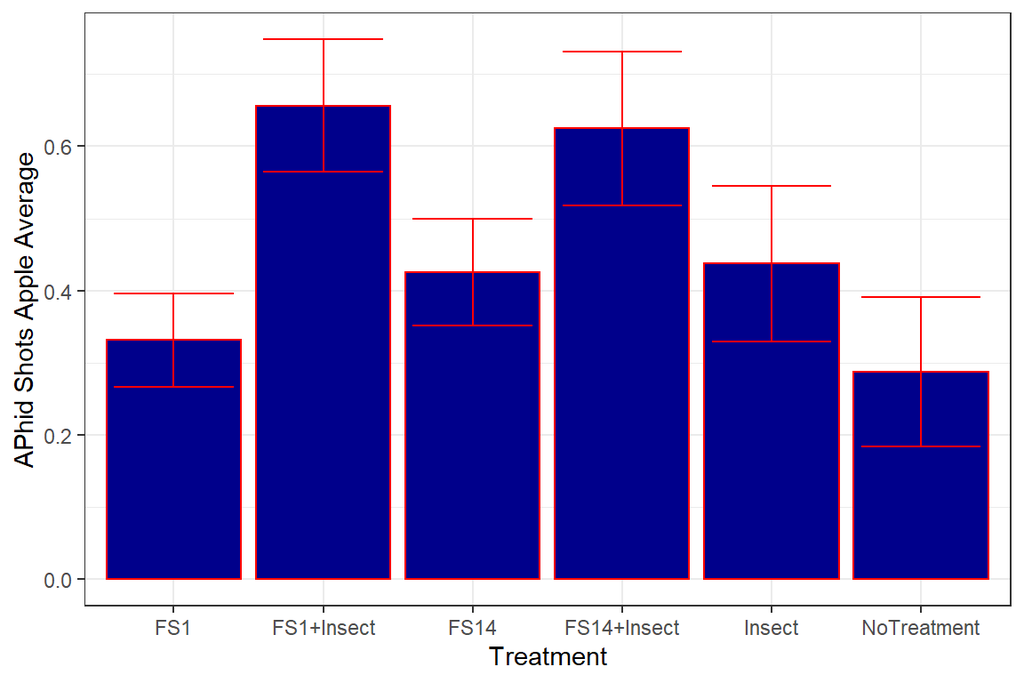

```r
##Boxplots
error_bars_aphid_shoots_Apple <- ggplot(Aphid_shoots_Apple,aes(treatment,aphid_shoots))+
  geom_bar(fill="darkblue",stat = "summary",fun="mean",col="red")+xlab("Treatment")+
  geom_errorbar(stat='summary', width=0.8,position = "dodge",col="red")+
  theme_bw()+ylab("APhid Shots Apple Average");error_bars_aphid_shoots_Apple
```

```r
#Save plot
ggsave("error_bars_aphid_shoots_Apple.tiff", units="in", width=10, height=5, dpi=300, compression = 'lzw')
```

From the visual comparison, it can be observed that the treatment `FS1+Insect` has the higher value Aphid Shoots Apple as compared to all other treatments. Similarly, all the other differences can be asses by observing the visualization.